# Reproducible Research: Peer Assessment 1

It is now possible to collect a large amount of data about personal movement using activity monitoring devices such as a Fitbit, Nike Fuelband, or Jawbone Up. These type of devices are part of the “quantified self” movement - a group of enthusiasts who take measurements about themselves regularly to improve their health, to find patterns in their behavior, or because they are tech geeks. But these data remain under-utilized both because the raw data are hard to obtain and there is a lack of statistical methods and software for processing and interpreting the data.

This assignment makes use of data from a personal activity monitoring device. This device collects data at 5 minute intervals through out the day. The data consists of two months of data from an anonymous individual collected during the months of October and November, 2012 and include the number of steps taken in 5 minute intervals each day.

## Loading and preprocessing the data

We downloaded the data on 8/7/2014 from URL <- “https://d396qusza40orc.cloudfront.net/repdata/data/activity.zip” and unzipped the file (dated 2/11/2014).  
Here’s the code needed to:

1. Load the data.
2. Process/transform the data into a format suitable for our analysis.

```r
activ<-read.csv("activity.csv")
activ<-cbind(activ, hourmin=activ[,3])
activ$hourmin<-as.character(activ$hourmin)
activ$hourmin[]<-paste("000",activ$hourmin[],sep="")
activ$hourmin[]<-substr(activ$hourmin[],nchar(activ$hourmin[])-3,nchar(activ$hourmin[]))
activ$hourmin[]<-paste(substr(activ$hourmin[],1,2),substr(activ$hourmin[],3,4),sep=":")
```

## What is the mean total number of steps taken per day?

For this part of the assignment, we ignore the missing values in the dataset.

1. We make a histogram of the total number of steps taken each day.

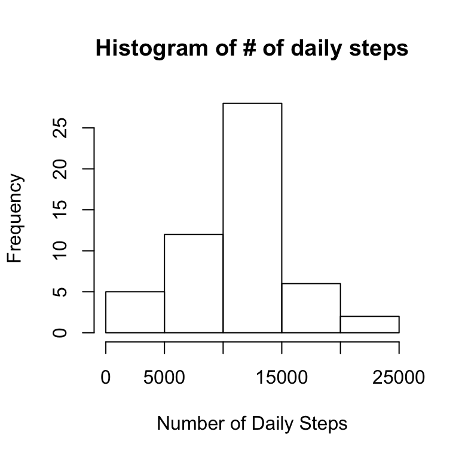

```r
sumsteps<-tapply(activ$steps,activ$date,sum)
hist(sumsteps, main="Histogram of # of daily steps",xlab="Number of Daily Steps")
```

2. We calculate and report the mean and the median of the total number of steps taken per day.

```r
meansteps<-mean(sumsteps,na.rm = TRUE)
mediansteps<-median(sumsteps,na.rm = TRUE)
```

The mean of the total number of daily steps is 10766 and the median is 10765.

## What is the average daily activity pattern?

1. We display a time series plot (i.e. type = “l”) of the 5-minute interval (x-axis) and the average number of steps taken, averaged across all days (y-axis)
2. We then show the 5-minute interval, on average across all the days in the dataset, that contains the maximum number of steps.

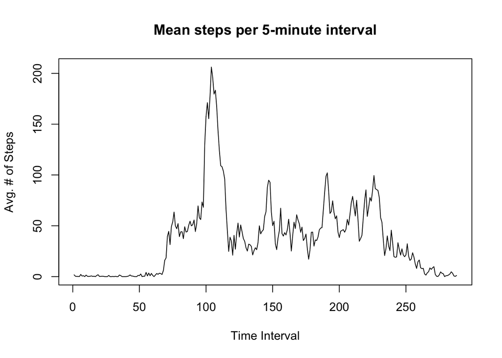

```r
avginterv<-aggregate(activ$steps, by = list(as.factor(activ$hourmin)), FUN = mean, na.rm=T)
plot(avginterv$x, type="l", xlab="Time Interval", ylab="Avg. # of Steps", main="Mean steps per 5-minute interval")
```

```r
maxsteps<-avginterv$Group.1[avginterv$x==max(avginterv$x)]
maxstepsend<-avginterv$Group.1[which(avginterv$Group.1==maxsteps ) + 1]
```

The 5-minute interval with the maximum numer of steps is 08:35-08:40.

## Imputing missing values

We should take into account that there are a number of days /intervals where there are missing values (coded as NA). The presence of missing days may introduce bias into some calculations or summaries of the data.

```r
missval<-sum(!complete.cases(activ))
```

The dataset has 2304 missing values.

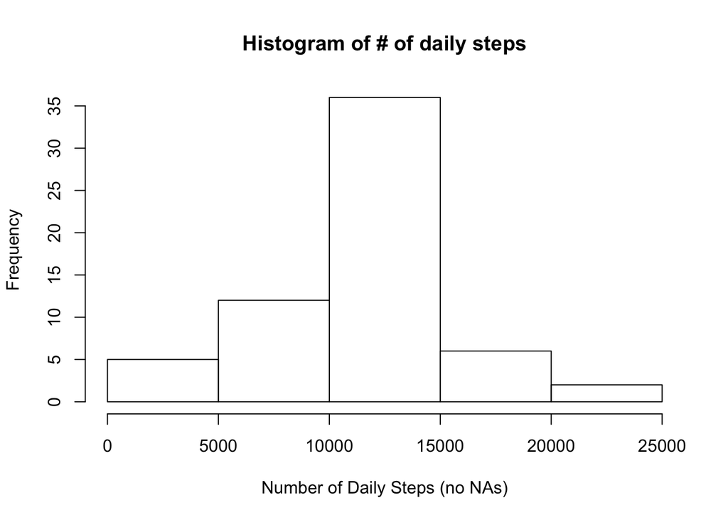

```r
activimp<-activ
for (i in which(sapply(activimp, is.numeric))) {
    activimp[is.na(activimp[, i]), i] <- mean(activimp[, i],  na.rm = TRUE)
}
sumsteps2<-tapply(activimp$steps,activ$date,sum)
hist(sumsteps2, main="Histogram of # of daily steps",xlab="Number of Daily Steps (no NAs)")
```

```r
meansteps2<-mean(sumsteps2)
mediansteps2<-median(sumsteps2)
```

The mean of the total number of daily steps with imputed data is 10766 and the median is 10766.

## Are there differences in activity patterns between weekdays and weekends?

For this part the weekdays() function may be of some help here. We use the dataset with the filled-in missing values for this part.

[figure not shown]

```r
activimp[,5]<-as.POSIXlt(activimp$date)$wday
for (i in 1:nrow(activimp)) {
    if ((activimp[i,5]==0) | (activimp[i,5]==6)) {
        activimp[i,5]<-"weekend"
    }
    else activimp[i,5]<-"weekday"
}
activimp[,5]<-factor(activimp$V5)
par(mfrow = c(2, 1))
activimpd<-activimp[activimp[,5]=="weekday",]
activimpe<-activimp[activimp[,5]=="weekend",]
avgintervd<-aggregate(activimpd$steps, by = list(as.factor(activimpd$hourmin)), FUN = mean, na.rm=T)
plot(avgintervd$x, type="l", xlab="Time Interval", ylab="Avg. # of Steps", main="Mean steps per 5-minute interval on weekdays")
avginterve<-aggregate(activimpe$steps, by = list(as.factor(activimpe$hourmin)), FUN = mean, na.rm=T)
plot(avginterv$x, type="l", xlab="Time Interval", ylab="Avg. # of Steps", main="Mean steps per 5-minute interval on weekends")
```

[output not shown]